# PredictingGrades

```r
Math325Grades_Train <- read.csv("~/Desktop/Statistics-Notebook/Data/Math325Grades_Train.csv", head = TRUE)
Math325Grades_Test <- read.csv("~/Desktop/Statistics-Notebook/Data/Math325Grades_Test.csv", head=TRUE)
```

### Finding model

**attempt1**

```r
glm <- glm(FinalGrade == "A" ~ I(SkillsQuizzesTotal + ClassActivitiesTotal    + FinalExam + ProjectTotal + Analysis7), data=Math325Grades_Train)

pander(summary(glm))
```

|  | Estimate | Std. Error | t value | Pr(>\|t\|) |
| --- | --- | --- | --- | --- |
| **(Intercept)** | -0.5906 | 0.1533 | -3.851 | 0.0001913 |
| **I(SkillsQuizzesTotal + ClassActivitiesTotal + FinalExam + ProjectTotal + Analysis7)** | 0.02531 | 0.003527 | 7.177 | 6.815e-11 |

(Dispersion parameter for gaussian family taken to be 0.1765326 )

| Null deviance: | 29.93 on 119 degrees of freedom |
| --- | --- |
| Residual deviance: | 20.83 on 118 degrees of freedom |

`AIC = 136.47`

**attempt2**

```r
glm2 <- glm(FinalGrade == "A" ~ I(SkillsQuizzesTotal + ClassActivitiesTotal + Math325NotebookOrganization), data=Math325Grades_Train)

pander(summary(glm2))
```

|  | Estimate | Std. Error | t value | Pr(>\|t\|) |
| --- | --- | --- | --- | --- |
| **(Intercept)** | -0.4143 | 0.1852 | -2.237 | 0.02714 |
| **I(SkillsQuizzesTotal + ClassActivitiesTotal + Math325NotebookOrganization)** | 0.04315 | 0.008752 | 4.93 | 2.718e-06 |

(Dispersion parameter for gaussian family taken to be 0.2102912 )

| Null deviance: | 29.93 on 119 degrees of freedom |
| --- | --- |
| Residual deviance: | 24.81 on 118 degrees of freedom |

`AIC = 157.42`

**attempt3**

```r
glm3 <- glm(FinalGrade == "A" ~ I(SkillsQuizzesTotal + ClassActivitiesTotal ), data=Math325Grades_Train)

pander(summary(glm3))
```

|  | Estimate | Std. Error | t value | Pr(>\|t\|) |
| --- | --- | --- | --- | --- |
| **(Intercept)** | -0.293 | 0.1752 | -1.672 | 0.09708 |
| **I(SkillsQuizzesTotal + ClassActivitiesTotal)** | 0.04736 | 0.01048 | 4.518 | 1.489e-05 |

(Dispersion parameter for gaussian family taken to be 0.2161973 )

| Null deviance: | 29.93 on 119 degrees of freedom |
| --- | --- |
| Residual deviance: | 25.51 on 118 degrees of freedom |

`AIC = 160.74`

**attempt4**

```r
glm4 <- glm(FinalGrade == "A" ~ I(ClassActivitiesTotal + Analysis13+Math325NotebookOrganization), data=Math325Grades_Train, family = binomial)
pander(summary(glm4))
```

|  | Estimate | Std. Error | z value | Pr(>\|z\|) |
| --- | --- | --- | --- | --- |
| **(Intercept)** | -21.47 | 7.7 | -2.788 | 0.005301 |
| **I(ClassActivitiesTotal + Analysis13 + Math325NotebookOrganization)** | 1.82 | 0.6476 | 2.811 | 0.004937 |

(Dispersion parameter for binomial family taken to be 1 )

| Null deviance: | 68.59 on 49 degrees of freedom |
| --- | --- |
| Residual deviance: | 48.00 on 48 degrees of freedom |

51.996

**attempt5**

```r
glm5 <- glm(FinalGrade == "A"  ~ I(ClassActivitiesTotal + FinalExam), data=Math325Grades_Train,family = binomial)
pander(summary(glm5))
```

|  | Estimate | Std. Error | z value | Pr(>\|z\|) |
| --- | --- | --- | --- | --- |
| **(Intercept)** | -6.904 | 1.446 | -4.773 | 1.812e-06 |
| **I(ClassActivitiesTotal + FinalExam)** | 0.4256 | 0.08862 | 4.802 | 1.568e-06 |

(Dispersion parameter for binomial family taken to be 1 )

| Null deviance: | 166.1 on 119 degrees of freedom |
| --- | --- |
| Residual deviance: | 122.3 on 118 degrees of freedom |

**attempt6**

```r
glm6 <- glm(FinalGrade == "A"  ~ I(FinalExam + Math325Grades_Train$ProjectTotal), data=Math325Grades_Train,family = binomial)
pander(summary(glm6))
```

|  | Estimate | Std. Error | z value | Pr(>\|z\|) |
| --- | --- | --- | --- | --- |
| **(Intercept)** | -12.89 | 2.657 | -4.851 | 1.228e-06 |
| **I(FinalExam + Math325Grades_Train$ProjectTotal)** | 0.5026 | 0.1025 | 4.902 | 9.503e-07 |

(Dispersion parameter for binomial family taken to be 1 )

| Null deviance: | 166.1 on 119 degrees of freedom |
| --- | --- |
| Residual deviance: | 105.9 on 118 degrees of freedom |

109.9

```r
#plot(FinalGrade == "A"  ~ I(FinalExam + ProjectTotal), data=Math325Grades_Train)
#b  <- coef(glm6)
#curve(exp(b[1]+b[2]*x)/(1+exp(b[1]+b[2]*x)),add =TRUE)
```

### Model

#### Logistic Model

$$P(Y_i = 1|x_i) = \frac{e^{\beta_0+\beta_1 x_i}}{1+e^{\beta_0 + \beta_1 x_i}} = \pi_i$$

- $Y_i = 1$ Indicate an A final grade
- $Y_i=0$ Indicate a final grade other than A
- $x_i$ is the Fianlexam + Analysis13 score.

$$H_0: \beta_1 = 0 \\
H_a: \beta_1 \neq 0$$

#### Fitting the Model

```r
glm7 <- glm(FinalGrade == "A"  ~ I(FinalExam +Analysis13), data=Math325Grades_Train,family = binomial)
summary(glm7)
```

```
##
## Call:
## glm(formula = FinalGrade == "A" ~ I(FinalExam + Analysis13),
##     family = binomial, data = Math325Grades_Train)
##
## Deviance Residuals:
##      Min        1Q    Median        3Q       Max
## -2.68646  -0.50386  -0.00841   0.54150   1.43015
##
## Coefficients:
##                           Estimate Std. Error z value Pr(>|z|)
## (Intercept)               -10.2493     3.0274  -3.386 0.000710 ***
## I(FinalExam + Analysis13)   0.6671     0.1952   3.417 0.000634 ***
## ---
## Signif. codes:  0 '***' 0.001 '**' 0.01 '*' 0.05 '.' 0.1 ' ' 1
##
## (Dispersion parameter for binomial family taken to be 1)
##
##     Null deviance: 68.593  on 49  degrees of freedom
## Residual deviance: 34.895  on 48  degrees of freedom
##   (70 observations deleted due to missingness)
## AIC: 38.895
##
## Number of Fisher Scoring iterations: 6
```

The estimated model is
$$P(Y_i = 1|\, x_{i}= \frac{e^{-10.2493 + 0.6671} }{1+e^{-10.2493 + 0.6671 }} = \hat{\pi}_i$$

`FianlExam + Analysis13` has significant p-value(0.0006338) that gives sufficient evidence to conclude $\beta_1\neq0$. It allows us to conclude that `FianlExam+Analaysis13` effects the probability of Fianl grade A.

#### Visualizing the Model

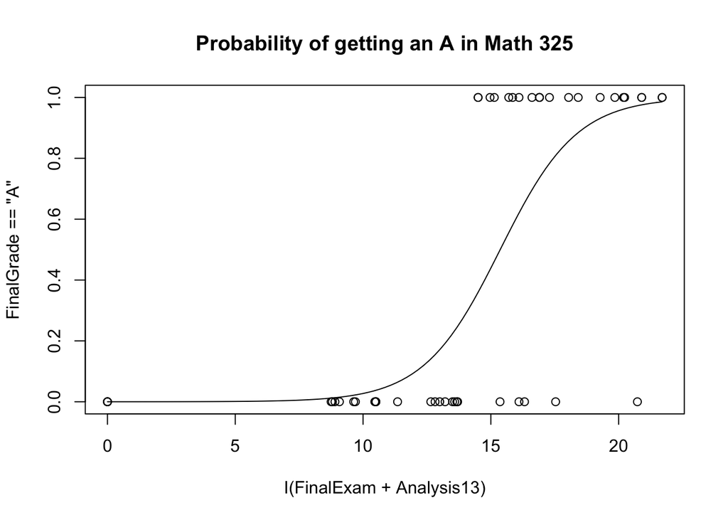

```r
plot(FinalGrade == "A"  ~ I(FinalExam + Analysis13), data=Math325Grades_Train, main = "Probability of getting an A in Math 325")
b  <- coef(glm7)
curve(exp(b[1]+b[2]*x)/(1+exp(b[1]+b[2]*x)),add =TRUE)
```

#### Interpretation

The value of $e^{b_0}$ is not interpretable. The value of $e^{b_1} = e^{0.6671} \approx 1.948578$ shows that the odds of the final grade increases by a factor of 1.95 for every 1 point increases on `fianl exam + analysis13`.

### Validation

```r
set.seed(121)
keep <- sample(1:nrow(Math325Grades_Train), 45)
train <- Math325Grades_Train[keep,]
test <- Math325Grades_Train[-keep,]
glm.valid <- glm(FinalGrade == "A"  ~ I(FinalExam +Analysis13), data = test, family=binomial)
predictions <- ifelse(predict(glm.valid, test, type="response") > 0.4, "A", "Other")
table(predictions, test$FinalGrade == "A")
```

```
##
## predictions FALSE TRUE
##       A         2   12
##       Other    12    0
```

My validation is 92%.